# CRIM 595 Final Project

Shelby Rothberg

20 July 2023

# Packages

# Data

## Acquire Data

### Bus Stop Data

```r
bus.stops <- read_sheet('https://docs.google.com/spreadsheets/d/1OLjEjJJiyjuu5arluv2oiorM4TqzqIk7PQJ9g4Ichvo')
```

```
## ✔ Reading from "bus stops".
```

```
## ✔ Range 'Sheet1'.
```

```
## ✖ Request failed [429]. Retry 1 happens in 6 seconds ...
```

```r
pts.bus <- st_as_sf(bus.stops, coords = c("LONGITUDE", "LATITUDE"), crs=default.crs)
```

### Crime Data

```r
id.crime <- "1Hdhg5dvPsb28gvkroUU99AKPcGu8rVCp"
crime.full <- read.csv(sprintf("https://docs.google.com/uc?id=%s&export=download", id.crime))
```

## Wrangle Data

### Format date and clean data

```r
crime.full$date.report <- as.Date(crime.full$date.report)
crime.full$dow <- weekdays(crime.full$date.report)
crime.full$day <- day(crime.full$date.report)
crime.full$month <- substr(crime.full$date.report, 6, 7)
crime <- subset(crime.full, !is.na(crime.full$lat))
```

### Filter since Covid-19 pandemic began and format as points

```r
crime <- crime %>% filter(date.report > '2020-03-01')
pts.crime <- st_as_sf(crime, coords = c("lon", "lat"), crs=default.crs)
```

### Create barriers around bus stops and join with crime data

```r
facility.buffer <- st_buffer(pts.bus, 25)
facility.activity <- st_join(pts.crime, left = FALSE, facility.buffer["Bus"])
facility.activity <- facility.activity %>% left_join(crime, by = 'ID')
facility.activity <- facility.activity[c(1:23,43)]
names(facility.activity) <- c("number", "date1", "time1", "type", "date2",
                              "time2", "statute", "crime", "crime.description",
                              "statute.description", "date.report", "time.report",
                              "hour1", "hour2", "hour.report", "year", "ID", "dow",
                              "day", "month", "Bus", "lat", "lon", "geometry")
```

# Findings

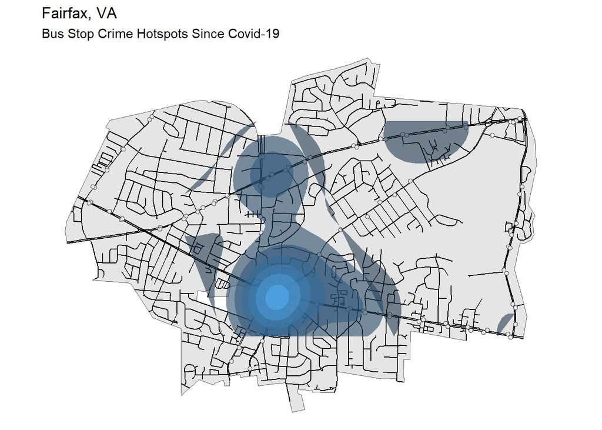

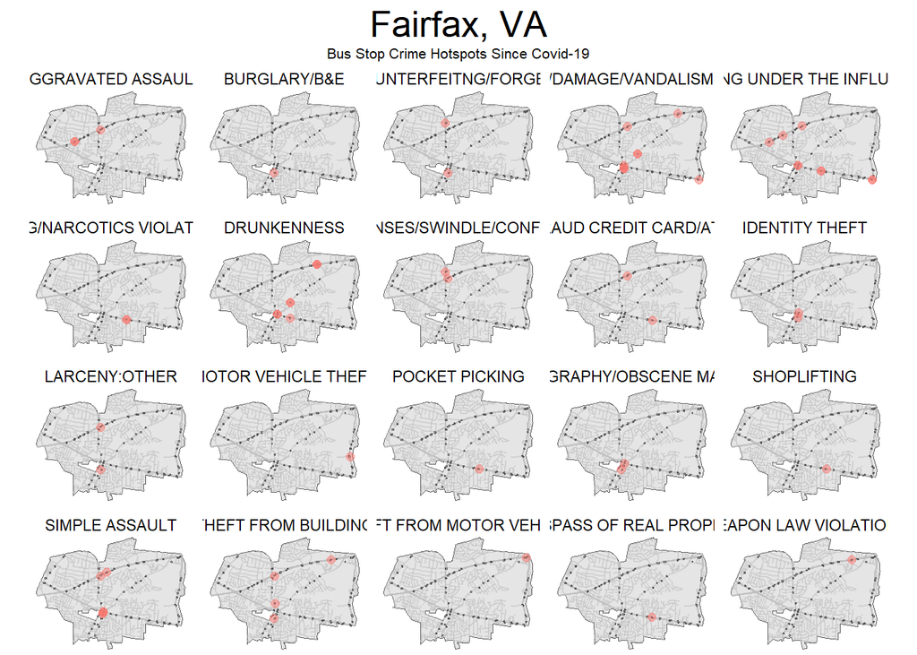

### Cluster Map of Crime Around Bus Stops Since Covid-19 Pandemic Began

[interactive chart not shown]

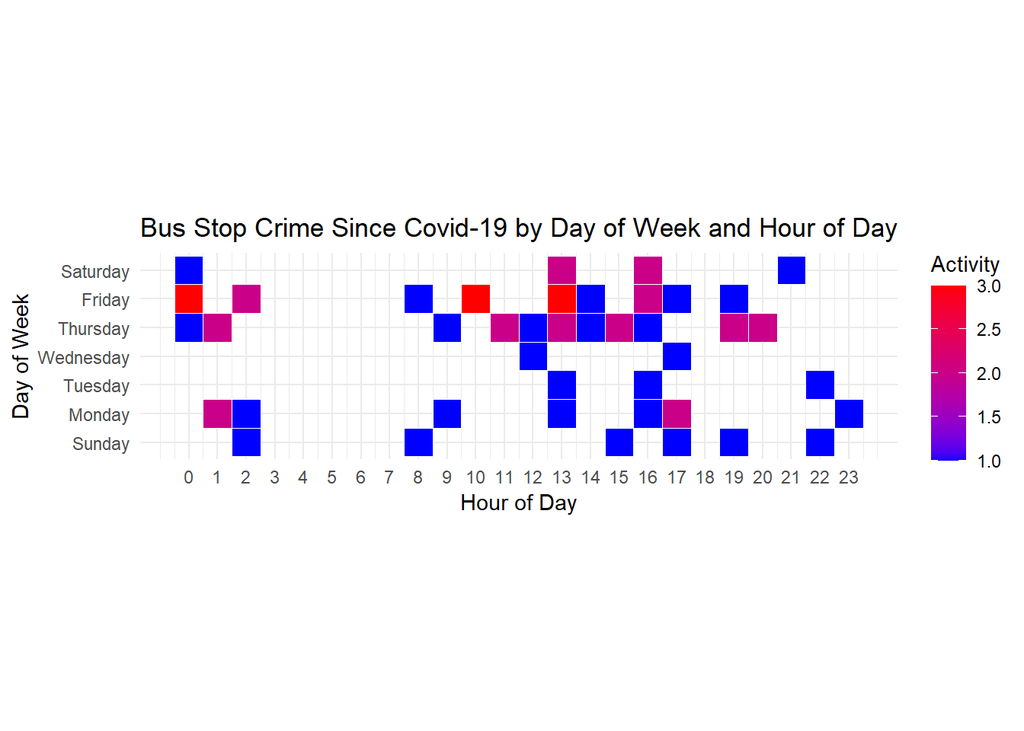

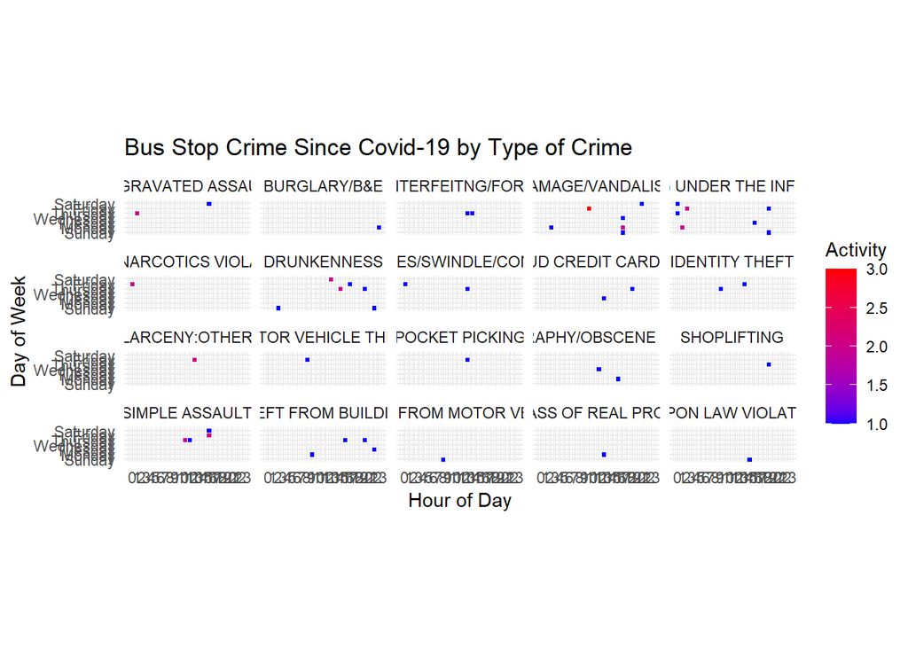

# Analysis

## Behavior

Since the Covid-19 pandemic began in March 2020, there have been few crimes reported around bus stops within the city of Fairfax, Virginia. The two most common types of crime reported around bus stops are destruction/damage/vandalism of property and driving under the influence with each making up 15% of all crime reported around bus stops. The other two types of crime that have been reported at a higher frequency are drunkenness (13.3%) and simple assault (10%). What types of crime are most commonly reported varies depending on the bus. Bus 29K has had the most crime reported, with driving under the influence being the most common and making up 18.75% of the crimes that occur around that particular bus. Additionally, bus 1C has a higher frequency of crime reported around it, with the most common types of crime being driving under the influence, drunkenness, and aggravated assault, where each type of crime comprises 15% of crime reported around that specific bus.

During the remainder of 2023, it can be predicted that the most common types of crime that will be reported around bus stops are destruction/damage/vandalism of property and driving under the influence, as these have been the most commonly reported types of crime since the start of the Covid-19 pandemic. Additionally, a higher frequency of drunkenness and simple assault can be predicted to occur around bus stops as well, but at a lower frequency than destruction/damage/vandalism of property and driving under the influence. It can also be predicted that the bus that will have the most crime reported during the remainder of 2023 is bus 29K, with driving under the influence being the most common type of crime reported. Bus 1C is also likely to continue to have a higher frequency of crime reported around it, with driving under the influence, drunkenness, and aggravated assault being the most common types of crime around that bus.

## Space

There are five major hotspots for reported crime around bus stops. The hotspot with the highest frequency of crime reported occurs around the intersection of Main Street and Blenheim Boulevard. The types of crime that occur within this hotspot are burglary/b&e, counterfeiting/forgery, destruction/damage/vandalism of property, driving under the influence, drug/narcotics violations, drunkenness, fraud credit card/ATM, identity theft, pornography/obscene material, pocket picking, larceny, simple assault, and theft from building. The next hotspot with the second highest frequency of crime reported occurs along Fairfax Boulevard between the intersections of Chain Bridge Road and University Drive. The types of crime that have been reported within this hotspot are counterfeiting/forgery, destruction/damage/vandalism of property, driving under the influence, false pretenses/swindle/confidence game, fraud credit card/ATM, aggravated assault, larceny, simple assault, and theft from building. The next hotspot also occurs along Fairfax Boulevard, but between the intersections of Lion Run and Draper Drive. The types of crime reported within this hotspot are destruction/damage/vandalism of property, drunkenness, theft from building, theft from motor vehicle, and weapon law violations. The fourth hotspot occurs between the intersection of Main Street and Pickett Road. The types of crime reported at this hotspot are destruction/damage/vandalism of property, driving under the influence, and motor vehicle theft. The fifth hotspot, which has the lowest frequency of crime reported compared to the other four hotspots, occurs at the intersection of Fairfax Boulevard and Fairchester Drive. The types of crime that occur at this hotspot are aggravated assault and driving under the influence. There are four major coldspots for crime reported around bus stops. The first spans from Chain Bridge Road to Jermantown Road around the Fairchester neighborhood. The second coldspot spans from Chain Bridge Road around Providence Park to Roberts Road, but not as far as Main Street as frequent activity is reported there. The third coldspot occurs at the Army Navy Country Club encompassed by Blenheim Boulevard, Pickett Road, and Main Street, however, the coldspot only expands up until these three major roads as the roads have high frequencies of crime reported. The final coldspot occurs in the Mosby Woods neighborhood encompassed by Fairfax Boulevard and I-66.

Bus stops located near the intersection of Main Street and Blenheim Boulevard are most likely to experience the highest frequency of reported crime for the remainder of 2023. Specifically, the bus stop at the intersection of Main Street and University Drive next to Old Town Hall can be predicted to have the highest amount of crime reported. Additionally, bus stops around the intersection of Chain Bridge Road and Fairfax Boulevard can also be predicted to have high amounts of crime reported, especially at the bus stop located next to Denny’s restaurant and Exxon gas station. There is also more likely to be crime reported around the bus stops along Fairfax Boulevard between Draper Drive and Lion Run, specifically at the bus stop that occurs right at the intersection of Lion Run and Fairfax Boulevard, as well as the bus stop at the intersection of Draper Drive and Fairfax Boulevard. There is also likely to be more crime reported at the bus stop at the intersection of Main Street and Pickett Road next to the Little River Turnpike. Finally, it can be predicted that there will be higher amounts of crime reported at the bus stop at the intersection of Fairfax Boulevard and Walnut Street. The least amount of activity is likely to occur at the previously mentioned coldspots near the Fairchester neighborhood, Providence Park, the Army Navy Country Club, and Mosby Woods. This is likely because these areas are not near the three major roads with crime reported around bus stops which are Main Street, Pickett Road, and Fairfax Boulevard.